# pH maalinger

Lærke

5/10/2021

pH measurement to determine possible buffer properties of the 3 mM NaCl in RO water.  
Half of the samples were bobbled with atmospheric air overnight, to impact the carbonate system. About 500 mL solution was set to various pH, with 2M NaCl and 2M NaOH. When setting the pH it was very difficult to achieve a pH of 8, a lower concentration of acid and base could be used to set the pH.  
One samples was prepared with a sodium-bicarbonate-carbonate buffer with initial pH at 9.2. The pH was measure initially (time 0) and following the pH was set about time 15 min.

The First data displayed if of samples which were not bobbled with atmospheric air.

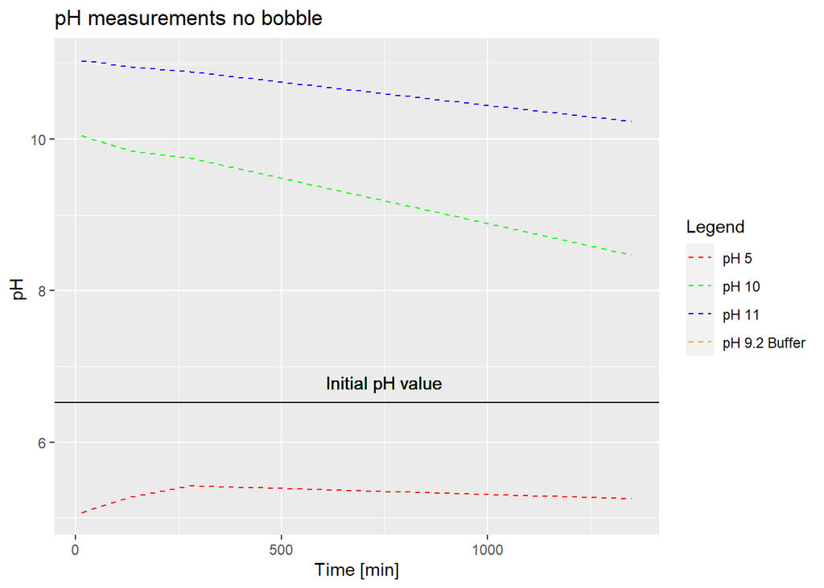

From the plot it is evident that all solutions go towards the initial pH at about pH 6.5. An outlier is the sample with pH 5 (red) which increase slightly and then decrease, the samples with pH 10 and 11 decrease.

The samples which had been bobbles over night is plotted in following plot.

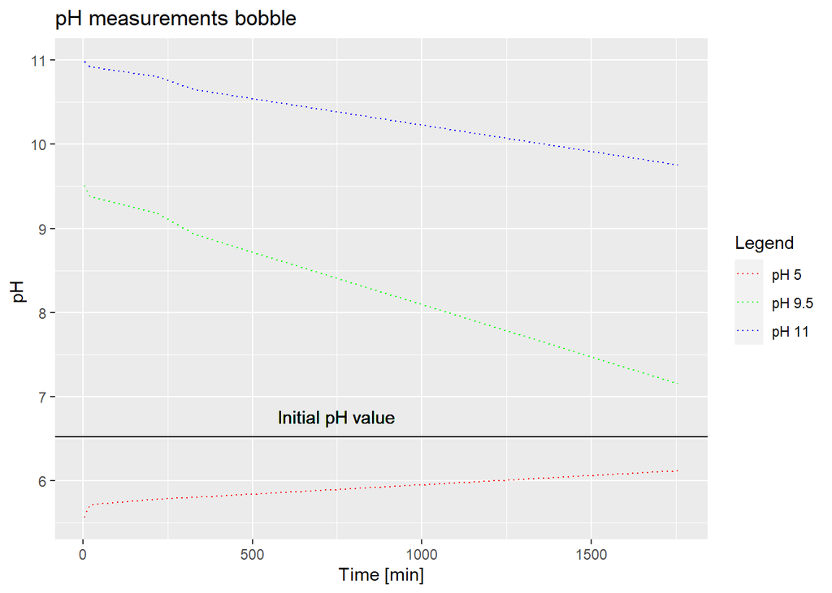

Comparison of pH measurement where the samples were bobbled with atmospheric air prior to change in pH, denoted b, and were the samples were not bobbled. The pH developmed of the buffer soluiton is also included in this plot.

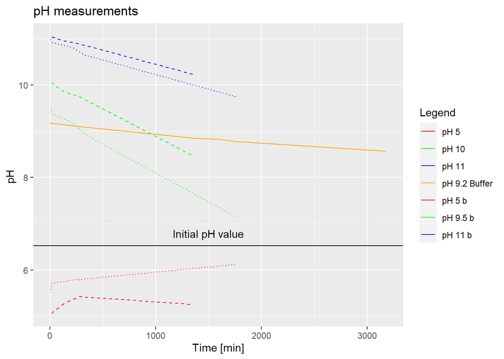

### Conclusion

It is necessary to use a buffer solution if the pH value should be kept constant.